# Mystery of Masks: Case Study from Covid-19

Edgar Mkhitaryan

# The problem/data description

## About the report

Due to pandemic, it is very important nowadays to understand how to prevent COVID-19 from spreading and whether the measures taken by the government are efficient enough. This study focuses on one of the most arguable questions regarding the pandemic, whether masks are an efficient way to stop the virus spread. Moreover, the symptoms of the virus will be analyzed and discussed.

Report web page: (https://edgarmkhitaryan.github.io/Covid-19-effectivenes-of-masks/)  
GitHub repository: (https://github.com/edgarmkhitaryan/Covid-19-effectivenes-of-masks/)

## Data description

The data for this study is provided by NetGenix. For more infromation regardnig the data you can visit this link (https://infogears.org/).

Data contains observations for 16768 individuals, mostly from the US. Also, it contains 33 variables, including gender, age, face covering, symptoms, exposure level, test results, etc. On the webpage of the project (https://infogears.org/dashboard/) we can see the dashboard created by the company. For example, there are some bar plots showing age vs. mask usage, age vs. mobility, etc.

## Getting familiar with data

To better understand the data we will analyze, let’s proceed with some descriptive plots. The figure below presents the distribution of ages by gender in the data. As can be observed, there are more females in all age intervals. Moreover, people are mostly between 36 and 75 age interval.

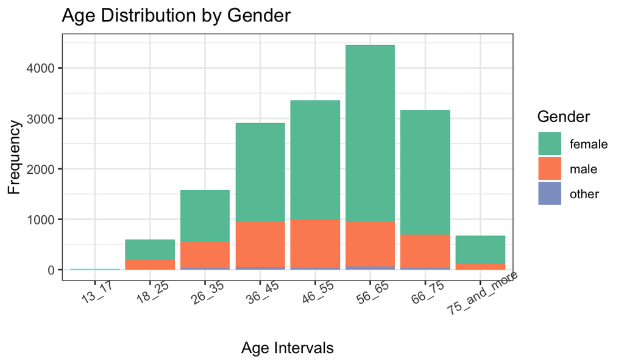

In the following figure, we can observe very low number of people with positive test results and those waiting for the results in all age intervals and genders. The majority of people are not tested at all. Moreover, we can see that females dominate in the dataset. To better understand the distribution of test results in the dataset, we can investigate the percentage of people by test results.

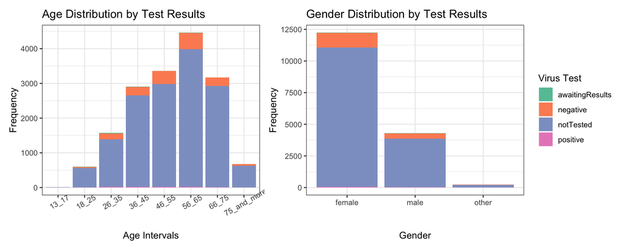

The figure below supports our previous finding of most people not being tested at all (89.69%), while only 0.59% have positive test results.

- Not tested 89.69%
- Positive tests 0.59%
- Negative tests 9.47%
- Awaiting results 0.25%

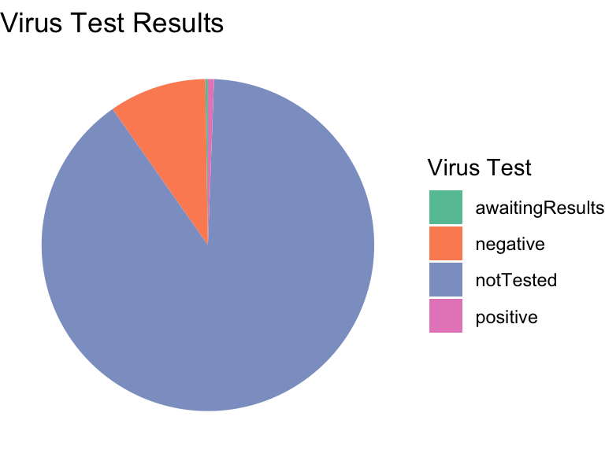

- Always 70.59%
- Never 4.29%
- Sometimes 25.12%

In the future analysis, the report will concentrate on whether the masks are efficient ways of protection from the virus or not.

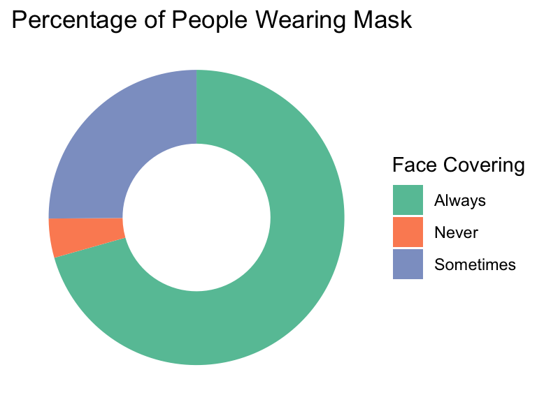

# Main hypotheses

The hypothesis for this report is whether the masks are efficient ways of protection from the virus.

# Analysis

The graph below depicts the number of times people left their houses by frequency of face covering. We can clearly see that more people are never wearing mask left home at least once. Hence, the future analysis of mask efficiency will be more accurate as people never wearing masks have a higher probability of being contaminated than those wearing masks, as stated by WHO.

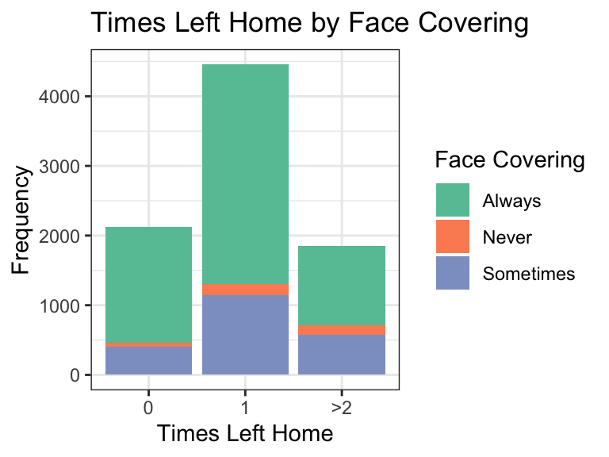

The graph below depicts the test results by face-covering frequency. We can observe very large number of people wearing masks in all three categories. Surprisingly, more than 80% of people who tested positive always wear masks.

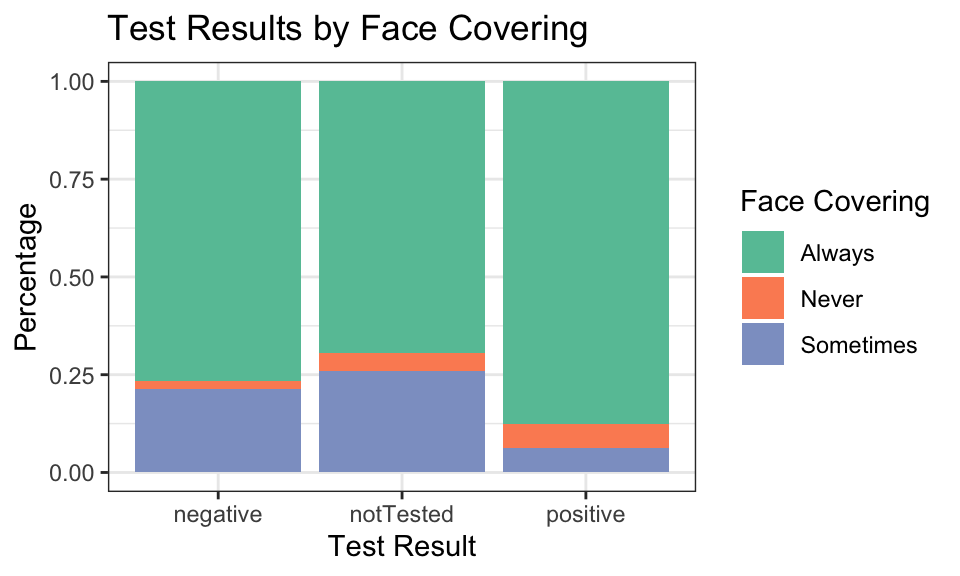

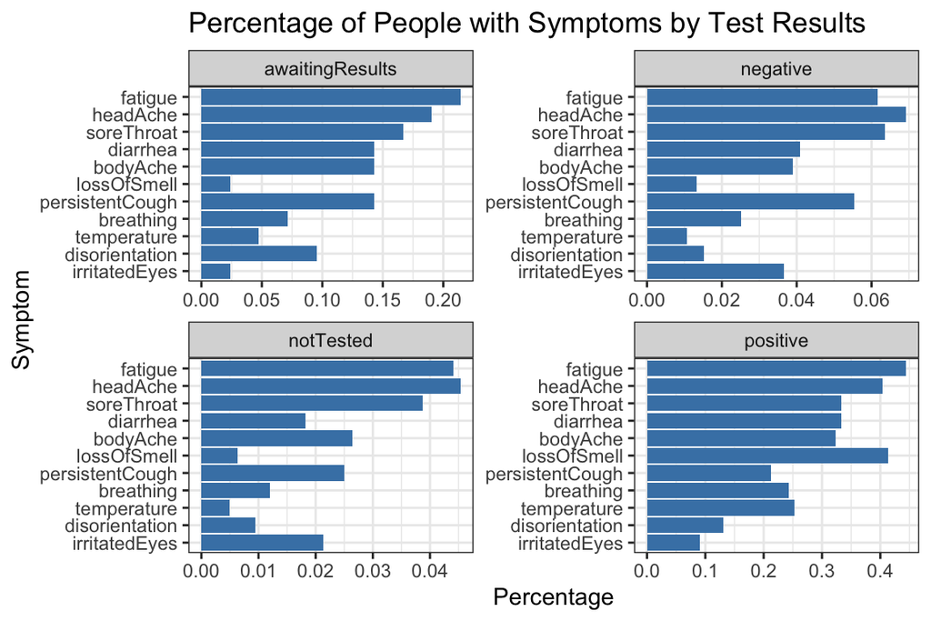

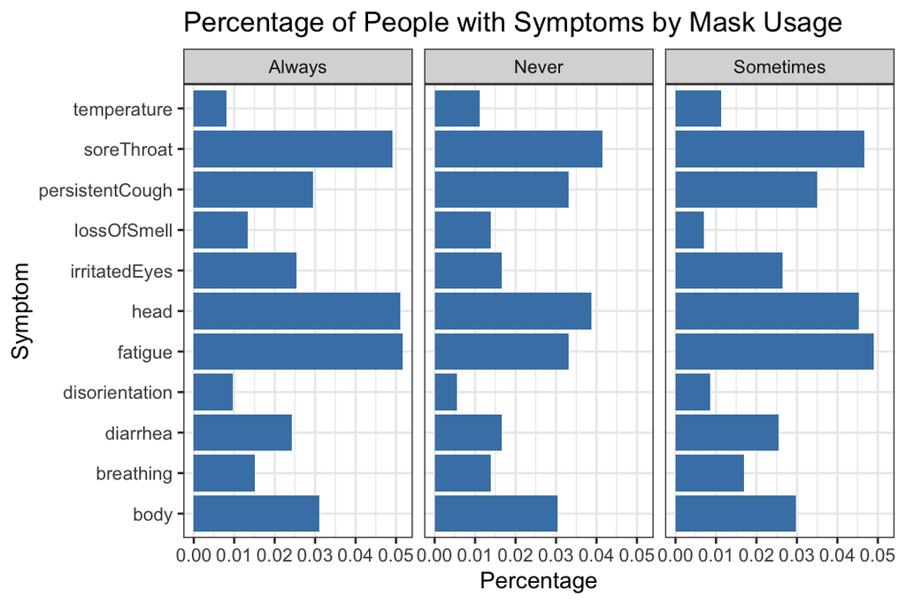

In the following bar chart, we can see that regardless of whether a person has symptoms or not, the distribution of face-covering frequency is the same. Hence we can imply that masks have nothing to do with having symptoms, thus, with being contaminated.

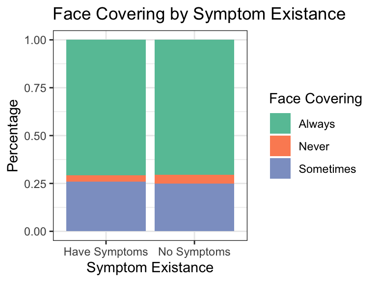

It would be also very interesting to observe how people end up when having direct contact with a contaminated person. The figure below shows the proportion of test results by each category of mask usage for people who had direct contact. We can observe a high proportion of positive cases for people never wearing masks. However, this data is not representative as there are only a few people who had direct contact and never wore masks. On the other hand, proportionally more people always wearing masks tested positive compared to those wearing masks occasionally. This again supports the notion that masks are not the best way to be protected from the virus.

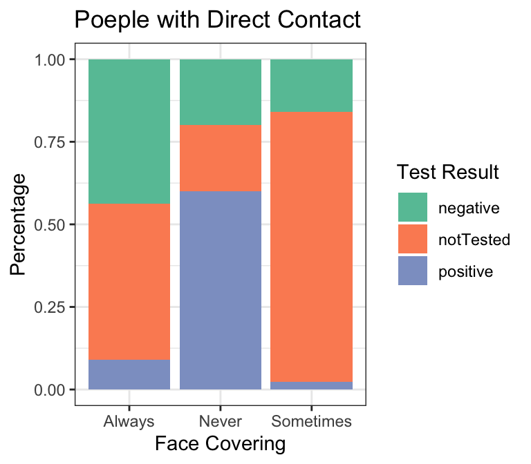

To further analyze the effect of the mask, we can investigate its impact on mental health. The graph below reveals that proportionally more people wearing masks have problems with mental health.

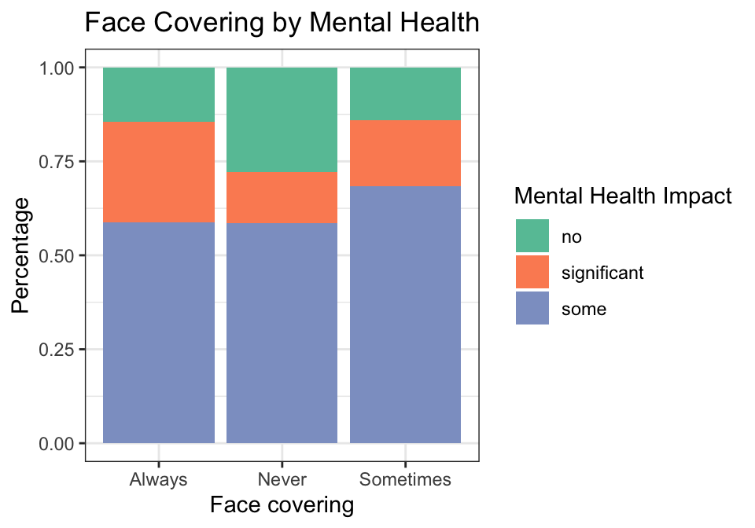

# Summary of findings